# Assignment 2

On The Nose (OTN)

March 22, 2018

# Cleaning Data

```r
library(readxl)
library(tidyverse)
library(plotly)
#Read in the file
survey <- read_csv("./data/survey.csv",
                   na = c("-",""," ","n/a", "NA")) %>%
#Removing NA survey submission
filter(id != 64)
#Performing repeated mutations at once
#Arrays of questions to be mutated (1 added to each Q number to reference column)
uppercase<-c(4,21,34)
lowercase<-c(5,7,10,19,26,33)
newline_removal<-c(3,5,6,7,10,14,19,26,33)

#performed after all other modifications to numerical cols
numbers<-c(3,6,11,14,22,23,24,25)

survey <- survey %>%
  #Convert True/False columns to uppercase
  mutate_at(.funs=(funs(str_to_upper(.))),uppercase) %>%
  #Conver short answer questions to lowercase
  mutate_at(.funs=(funs(str_to_lower(.))),lowercase) %>%
  #Removing newline characters
  mutate_at(.funs=(funs(sub("\n", "", .))),newline_removal)
```

After reading in the data, we first converted answers to true/false questions like Q3 into all upper case, and answers to short answer questions into lower case. Newline values were also stripped as several entries contained newline characters, likely due to user entry.

```r
#Cleaning Q2 data

#Changed 27th response to 2.0 directly as extra information was added including brackets
survey$Q2[27] <- "2.0"

#Removing extra strings/ expressions
survey <- survey %>%
  #Removing hour at the end for consistency
  mutate(Q2 = sub("(hour|hrs).*", "", Q2,ignore.case=TRUE)) %>%
  #Change fractions into decimal values
  mutate(Q2 = sub("1/2", "0.5", Q2)) %>%
  mutate(Q2 = sub("4/7", "0.57", Q2)) %>%
  #Remove confusing/meaningless entry
  mutate(Q2 = sub("three times", "", Q2))
```

Question 2 had some variation in answers- mainly those who added hours to the end of their answer or those who answered in fractions. Extra text was removed, and fractions were changed to decimal values.

```r
#Cleaning Q4 data
#Replace generic answer "music" with NA
survey$Q4[22] <- NA
survey <- survey %>%
  #Convert variations of genres to a standard value
  mutate(Q4 = sub("rnb", "r&b", Q4)) %>%
  mutate(Q4 = sub("popular", "pop", Q4)) %>%
  mutate(Q4 = sub(" music", "", Q4)) %>%
  mutate(Q4 = sub("alt ", "alternative ", Q4)) %>%
  mutate(Q4 = sub("-", " ", Q4)) %>%
  mutate(Q4 = sub("and/or roll", "", Q4)) %>%
  mutate(Q4 = sub("hiphop", "hip hop", Q4)) %>%
  mutate(Q4 = sub("pop ", "pop", Q4)) %>%
  mutate(Q4 = sub("rock ", "rock", Q4)) %>%
  mutate(Q4 = sub("hip pop", "hip hop", Q4))
```

Question 4 had several duplicate answers in various (mis)spellings- for example, hip hop was spelled with hyphens, spaces, and even misspelled. These variations were changed to a single value representing each genre.

```r
#Cleaning Q5 data
survey <- survey %>%
  #Removing hour for consistency
  mutate(Q5 = sub("(hour|hrs).*", "", Q5,ignore.case=TRUE)) %>%
  #Changing useless answer into a null value
  mutate(Q5 = sub("choosing not to answer", NA, Q5,ignore.case=TRUE))
```

```r
#Cleaning Q6 data
#Replacing answer "time" with "time control"
survey$Q6[55] <- "time control"

survey <- survey %>%
  #Changing similar answers into standard values
  mutate(Q6 = sub("teleporting", "teleportation", Q6)) %>%
  mutate(Q6 = sub("invisible", "invisibility", Q6)) %>%
  mutate(Q6 = sub("to never have to sleep", "not needing sleep", Q6)) %>%
  mutate(Q6 = sub(".*future.*", "forecasting", Q6)) %>%
  mutate(Q6 = sub(".*fly.*", "flight", Q6)) %>%
  mutate(Q6 = sub(".*(time-reverse|freeze|control).*", "time control", Q6)) %>%
  mutate(Q6 = sub(".*(past|can go to wherever).*", "time travel", Q6))
```

Questions 5 and 6 had similar issues to Questions 2 and 4 respectively, and were adjusted with pattern matching.

```r
#Cleaning Q9 data
survey <- survey %>%
  #Remove extra unecessary characters
  mutate(Q9 = gsub(".", "", Q9,fixed=TRUE)) %>%
  #Changing answers along the lines of "don't watch tv" to none
  mutate(Q9 = sub(".*(dont|don't|no).*", "none", Q9))
```

Several answers for Question 9 involved some variation of “none”, so duplicates were adjusted.

```r
#Cleaning Q13 data
survey <- survey %>%
  #Removing extra characters
  mutate(Q13 = sub("dollars", "", Q13)) %>%
  mutate(Q13 = sub("$", "", Q13,fixed=TRUE))
```

```r
#Cleaning Q18 data
#Added comma to make it easier to split
survey$Q18[34] <- "gym, internet surfing"

#Condensed similar answers
survey <- survey %>%
  mutate(Q18 = sub("(game |play games|gaming|play video games|computer games)", "games", Q18))
```

```r
#Cleaning Q21 data
#Changed to common unit
survey <- survey %>%
  mutate(Q21 = sub("7;30", "7.50", Q21))
```

```r
#Cleaning Q22 data
#Removing unecessary characters
survey <- survey %>%
  mutate(Q22 = sub("days", "", Q22))
```

```r
#Cleaning Q23 data
#Converted odd answers to the actual age
survey <- survey %>%
  mutate(Q23 = sub("1997|XXI", "21", Q23))
```

```r
#Cleaning Q24 data
#Replace text
survey <- survey %>%
  mutate(Q24 = sub("i don't know", NA, Q24))
```

```r
#Cleaning Q25 data
#Changing meaningless answers to NA
survey <- survey %>%
  mutate(Q25 = sub("yes|choosing not to answer", NA, Q25))
```

```r
#Cleaning Q32 data
#Changing for consistency
survey$Q32[50] <- "chopsticks"

#Converting all numeric answers to the correct type
survey <- survey %>%
  mutate_at(.funs=(funs(as.numeric(.))),numbers)
```

Several columns were numbers stored as character, so we changed the data type of those columns to Numeric for plotting

```r
#Cleaning up multivalue entries
survey <- survey %>%
  mutate(Q9 = sub("&", ",", Q9)) %>%
  separate(Q16, c("Q16", "Q16A", "Q16B"), sep = ",") %>%
  separate(Q9, c("Q9", "Q9A"), sep = "(, | , )") %>%
  mutate(Q18 = sub("/", ",", Q18)) %>%
  separate(Q18, c("Q18","Q18A", "Q18B", "Q18C"), sep = ", ")
```

Some columns were multivalued by design, such as the pet question, or were multivalued due to user entry, such as the tv streaming question and the hobby question. These were split into several columns to accommodate all values.

```r
#Recoding multiple choice answers to actual answers
survey <- survey %>%
  mutate(Q1=recode(Q1,"A"="1","B"="2","C"="3","D"="4","E"="Other")) %>%
  mutate(Q7=recode(Q7,"A"="two sizes too big","B"="one size too small","C"="neither of these")) %>%
  mutate(Q8=recode(Q8,"A"="[0,3)","B"="[3,6)","C"="[6,9)","D"="[9,12)","E"="More than 12")) %>%
  mutate(Q11=recode(Q11,"A"="elective","B"="core")) %>%
  mutate(Q12=recode(Q12,"A"="single","B"="double")) %>%
  mutate(Q14=recode(Q14,"A"="0","B"="1","C"="2","D"="3","E"="4","F"="5","G"="more than 5")) %>%
  mutate(Q15=recode(Q15,"A"="cucumbers","B"="carrots","C"="neither")) %>%
  mutate(Q16=recode(Q16,"A"="dog","B"="cat","C"="rabbit","D"="bird","E"="reptile","F"="other")) %>%
  mutate(Q17=recode(Q17,"A"="yes","B"="no")) %>%
  mutate(Q19=recode(Q19,"A"="Windows","B"="Mac","C"="Linux","D"="Other")) %>%
  mutate(Q26=recode(Q26,"A"="female","B"="male","C"="prefer not to answer")) %>%
  mutate(Q27=recode(Q27,"A"="fridge","B"="pantry")) %>%
  mutate(Q28=recode(Q28,"A"="0","B"="1-5","C"="6-10","D"="10-20","E"="more than 20")) %>%
  mutate(Q29=recode(Q29,"A"="yes","B"="no")) %>%
  mutate(Q30=recode(Q30,"A"="yes","B"="no")) %>%
  mutate(Q31=recode(Q31,"A"="yes","B"="no"))
```

Multichoice questions were finally recoded for plotting.

```r
#Write Data to file
write.csv(survey, file = "tidySurvey.csv")
```

# Graph: Year Levels

```r
year_level <- ggplot(data = survey,
                     aes(x = Q1,
                         text = paste("Year Level: ", Q1))) +
  geom_bar() +
  labs(x = "Year Level",
       title = "Q1. What year level are you in?")
ggplotly(year_level,
         tooltip = c("count", "text"))
```

```
## We recommend that you use the dev version of ggplot2 with `ggplotly()`
## Install it with: `devtools::install_github('hadley/ggplot2')`
```

[interactive chart not shown]

+ A surprising number of respondents weren’t first years despite it being a first year unit.

# Graph: Uni Commute

```r
commute <- ggplot(data = survey, aes(x = Q2)) +
  geom_histogram(binwidth = 0.5) +
  scale_x_continuous(limits = c(0, 31),
                     breaks = seq(0,30,5),
                     labels = seq(0,30,5)) +
  labs(x = "Commute length (hours)",
       title = "Q2. How much time do you spend commuting to university each week?")
ggplotly(commute)
```

```
## We recommend that you use the dev version of ggplot2 with `ggplotly()`
## Install it with: `devtools::install_github('hadley/ggplot2')`
```

[interactive chart not shown]

+ A majority of values were under 10 hours, but the range of values (0 ~ 120) was likely partially due to a misinterpreted question. Smaller values such as an hour or half an hour were likely a daily commute either in one way or in both directions, while larger ones may have been specified in minutes instead of hours, or the weekly total spent in commute.

- An extreme point was removed (120hrs) from the plot as it was most likely in the wrong unit. Even if it were the weekly total spent commuting to university, it would equate to 12 hrs spent in commute each way, which is far too impractical!
- A bin length of 0.5 was chosen due to the fact that many students tend to either round to the nearest half hour or quarter hour, and was favoured over 0.25 for legibility.

# Graph: Music taste

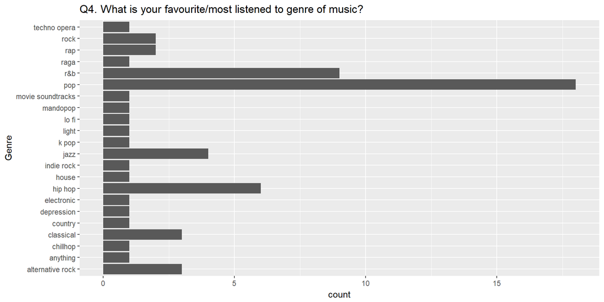

```r
survey %>%
  drop_na(Q4) %>%
  ggplot(aes(x = Q4)) +
  geom_bar() +
  labs(x = "Genre",
       title = "Q4. What is your favourite/most listened to genre of music?") +
  coord_flip()
```

+ Pop is by far the most popular genre, followed by r&b and hip-hop.

# Graph: Time spent on the Internet

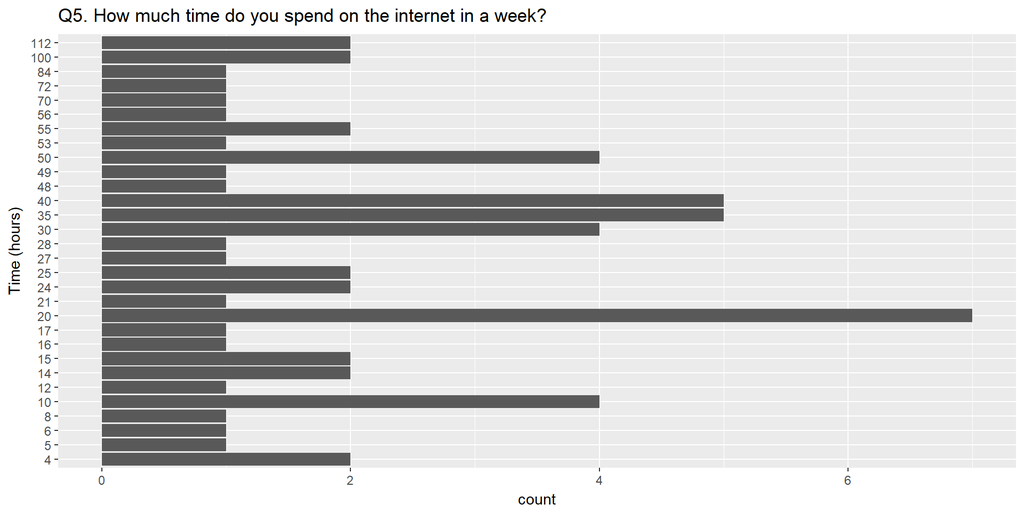

```r
survey %>%
  drop_na(Q5) %>%
  ggplot(aes(factor(Q5))) +
  geom_bar() +
  labs(x = "Time (hours)",
       title = "Q5. How much time do you spend on the internet in a week?") +
  coord_flip()
```

+ The highest frequency of hours spent on the Internet was 20 per week, or just under 3 hours a day.

# Graph: Music and Ed Sheeran Concert

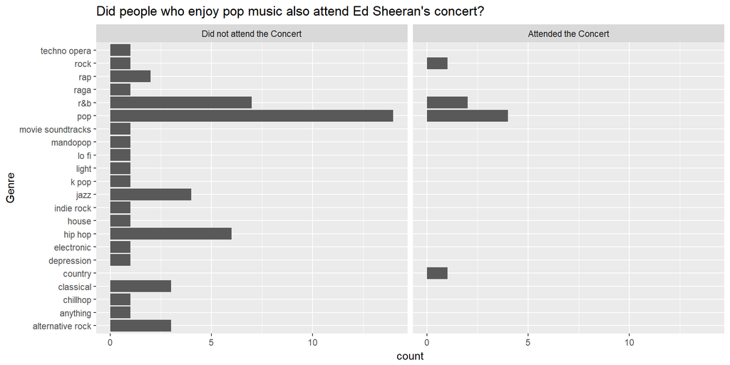

```r
#Create facet labeller for clarity
FL_Music_Concert <- c(
  "TRUE" = "Attended the Concert",
  "FALSE" = "Did not attend the Concert"
)
survey %>%
  #Dropping NA values
  drop_na(Q4) %>%
  ggplot(aes(x = Q4)) +
  geom_bar() +
  labs(x = "Genre",
       title = "Did people who enjoy pop music also attend Ed Sheeran's concert?") +
  coord_flip() +
  facet_wrap(~ Q3, labeller = as_labeller(FL_Music_Concert))
```

+ While there weren’t many who attended Ed Sheeran’s Concert, pop was the most popular genre of music amongst the respondents who did. This is not surprising, as Ed Sheeran is a predominantly pop/folk pop artist.

# Graph: Year levels of those struggling with the Unit

```r
year_struggle <-
  survey %>%
    ggplot(aes(x = Q1,
               fill = Q30,
               text = paste("Year Level: ", Q1, "<br>", "Struggling? ", Q30))) +
    geom_bar(position = "dodge") +
    labs(x = "Year Level",
         fill = "Struggling?",
         title = "How are different year levels handling this unit?")
ggplotly(year_struggle,
         tooltip = c("count", "text"))
```

```
## We recommend that you use the dev version of ggplot2 with `ggplotly()`
## Install it with: `devtools::install_github('hadley/ggplot2')`
```

[interactive chart not shown]

+ Of those who struggled, a majority were third year students, followed by equal amounts of second year and other miscellaneous year levels. Surprisingly, none of the first year respondents indicated that they were struggling with the unit, though it is also likely that not all first year students in the cohort responded.

- A greater number of students do not believe they are struggling with the unit.

# Graph: Coding experience of those struggling with the unit

```r
code_struggle <-
  survey %>%
    ggplot(aes(x = Q17,
               fill = Q30,
               #editing mouseover labels in ggplotly
               text = paste("Coding Experience? ", Q17, "<br>", "Struggling? ", Q30))) +
    geom_bar() +
    labs(x = "Coding experience",
         fill = "Struggling?",
         title = "How are students with different levels of coding experience handling this unit?")
ggplotly(code_struggle,
         tooltip = c("count","text"))
```

```
## We recommend that you use the dev version of ggplot2 with `ggplotly()`
## Install it with: `devtools::install_github('hadley/ggplot2')`
```

[interactive chart not shown]

+ While one might expect those with coding experience to struggle less with the unit, this was not the case with the respondents’ data.

- A majority of students struggling have actually got some coding experience, and a majority of students who have coding experience are also struggling. This may be due to the difference in syntax between their preferred language and R, or due to the different nature of the tasks required in the unit than previous units that required coding.

# Graph: Hours of study facetted by year of uni

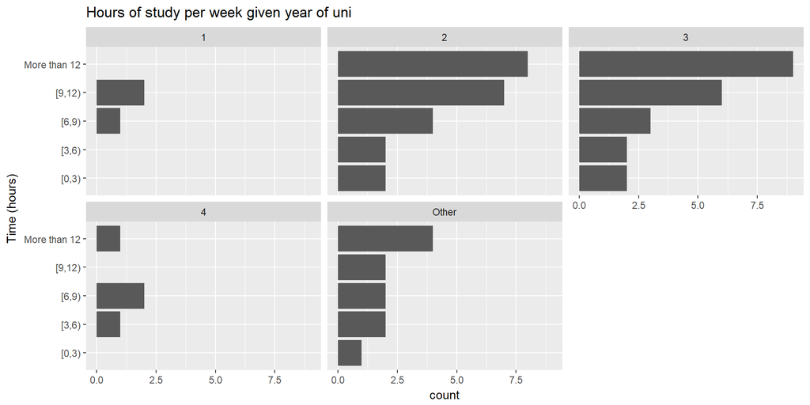

```r
survey %>%
  ggplot(aes(x =Q8)) +
  geom_bar() +
  labs(x = "Time (hours)",
       title = "Hours of study per week given year of uni") +
  facet_wrap(~Q1) +
  coord_flip()
```

- There was a greater proportion of 2nd and 3rd year students initially, which demonstrated a similar trend in number of hours studied. Were there similar amounts of first and fourth years, we may have observed a stronger pattern with those groups as well.

# Graph: Hours of study given type of degree

```r
degree<-survey %>%
  ggplot(aes(x =Q8,
             fill=Q12,
             text = paste("Hours of Study: ", Q8, "<br>", "Type of degree: ", Q12))) +
  geom_bar(position="dodge") +
  labs(x = "Time (hours)",
       fill = "Degree type",
       title = "Hours of study per week given type of degree")
ggplotly(degree, tooltip = c("count", "text"))
```

```
## We recommend that you use the dev version of ggplot2 with `ggplotly()`
## Install it with: `devtools::install_github('hadley/ggplot2')`
```

[interactive chart not shown]

+ Double degree students had a tendency to study for a greater number of hours than single degree students - however this may be due to a greater number of double degree students in the data set

# Graph: Number of times you see friends given the number of hours studied

```r
friends<- survey %>%
  ggplot(aes(x = Q22, text = paste("Friends Seen: ", Q22))) +
  geom_bar(position="dodge") +
  labs(x = "Number of times friends are seen",
       title = "Number of friends seen given hours of study per week") +
   facet_wrap(~Q8)
ggplotly(friends, tooltip = c("count", "text"))
```

```
## We recommend that you use the dev version of ggplot2 with `ggplotly()`
## Install it with: `devtools::install_github('hadley/ggplot2')`
```

[interactive chart not shown]

+ People who study more than 12 hours tend to see friends less, whilst those who study less tend to see friends more frequently.

- In particular, those who study between 9-12 hours per week seem to see their friends more regularly. This is again dependent on the whether more or less of the respondents tended to study more or less.